# OGTC Hackathon: Data analysis from Tesla vehicle

- by: Elon's Little Helpers
  - Chinedu Pascal Ezenkwu
  - Carlos Moreno-Garcia
  - John Guntoro
  - Joseph Sheratt
  - Darren Nicol

## Problem Setting

- By reverse-engineering the Tesla API, Intelligent Plant was able to download the data historian of the usage of a Tesla car (three months).
- $\approx182$ variables can be obtained.
- More information of these variable can be found [here](https://tesla-api.timdorr.com) (unofficial).
- Some information that can be obtained:
  - Screen status
  - Battery charge
  - Odometer data
  - Heating
  - Windshields
  - Fan
  - And much more!

## Gestalt tool API

- By querying $*car*$, one can visualise the different variables:

[figure not shown]

- You can plot different variables to see the performance across time:

[figure not shown]

## Data Analysis

**Installing the necessary packages**

```python
%pip install pandas matplotlib
```

**Importing the necessary packages**

```python
import intelligent_plant.app_store_client as app_store_client
import intelligent_plant.utility as utility
from os.path import expanduser
import matplotlib.pyplot as plt
import numpy as np
import pandas as pd
from math import *
```

**Getting the data from the repository**

```python
app_store = app_store_client.AppStoreClient(open(expanduser("~/.access_token"), "r").read())
data_core = app_store.get_data_core_client()
app_store.get_data_core_client()
app_store.get_user_info()
data_core.get_tags("FCBB05262EADC0B147746EE6DFB2B3EA5C272C33C2C5E3FE8F473D85529461CA.Edge Historian")
tags = {
    "FCBB05262EADC0B147746EE6DFB2B3EA5C272C33C2C5E3FE8F473D85529461CA.Edge Historian": [
        "StevesCar..response.vehicle_state.odometer",
        "StevesCar..response.charge_state.battery_level",
        "StevesCar..response.climate_state.outside_temp",
        "StevesCar..response.vehicle_state.center_display_state",
        "StevesCar..response.drive_state.speed",
        "StevesCar..response.climate_state.seat_heater_right"
    ]
}
```

**Data filtering**

- All interpolated data from 10 days ago in 3-minute intervals.

```python
resp = data_core.get_processed_data(tags, "*-10d", "*", "3m", "interp")
```

[output not shown]

[output cut: 380 more lines]

[output not shown]

**Plotting odometer data**

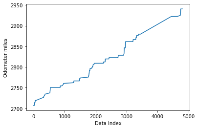

```python
df = utility.query_result_to_data_frame(resp)
plt.plot(df["StevesCar..response.vehicle_state.odometer"])
plt.xlabel('Data Index')
plt.ylabel('Odometer miles')
plt.show()
```

**Creation of a *new* differential dataset**

```python
import pandas as pd
type(df.loc[0].TimeStamp)
df.loc[1].TimeStamp-df.loc[0].TimeStamp
df_new=[]
for i in range(1,len(df)-1):
    df_new.append(df.loc[i]-df.loc[i-1])
df_new =pd.DataFrame(df_new)
```

**Distance travelled**

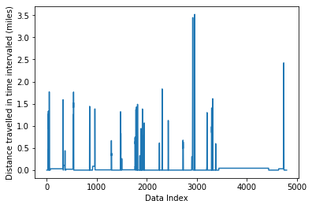

```python
plt.plot(df_new["StevesCar..response.vehicle_state.odometer"])
plt.ylabel('Distance travelled in time intervaled (miles)')
plt.xlabel('Data Index')
```

**Plotting the differential data on the battery level**

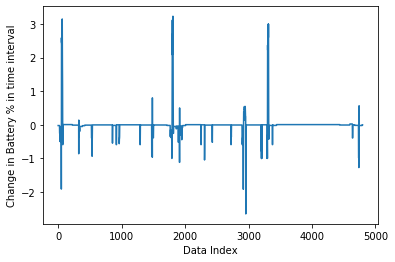

```python
plt.plot(df_new["StevesCar..response.charge_state.battery_level"])
plt.ylabel('Change in Battery % in time interval')
plt.xlabel('Data Index')
```

**Plotting efficiency**

- We created our own efficiency metric as the ratio between battery level differential and odometer differential.

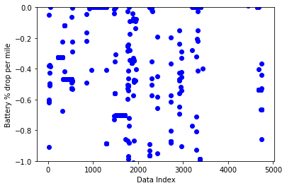

```python
df_new['Efficiency'] = df_new["StevesCar..response.charge_state.battery_level"]/df_new["StevesCar..response.vehicle_state.odometer"]
plt.plot(df_new['Efficiency'], 'bo')
plt.ylim([-1, 0])
plt.ylabel('Battery % drop per mile')
plt.xlabel('Data Index')
plt.show()
```

**Another view of the data**

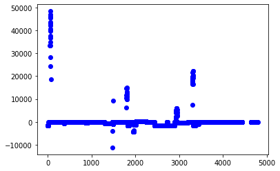

```python
df_new.replace(inf, 0)
df_new.replace(-inf, 0)
plt.plot(df_new['Efficiency'], 'bo')
```

**Histogram of efficiency metric**

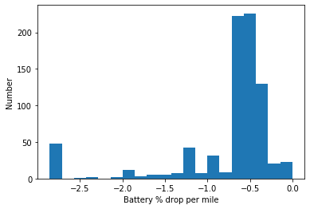

```python
eff=np.array(df_new["Efficiency"])
sh=np.array(df_new["StevesCar..response.climate_state.seat_heater_right"])
# Limit the efficiency between 0 and -3
eff2= eff[np.where(eff>-3)]
eff3 = eff2[np.where(eff2<0)]
plt.hist(eff3,bins=20)
plt.xlabel('Battery % drop per mile')
plt.ylabel('Number')
plt.show()
```

**Efficiency vs other variables**

- Here we compare our efficiency metric against other variables, such as speed or outside temp.
- Purpose: Try to find correlations.
- Speed may show some correlation, outside temperature does not.

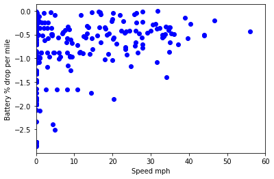

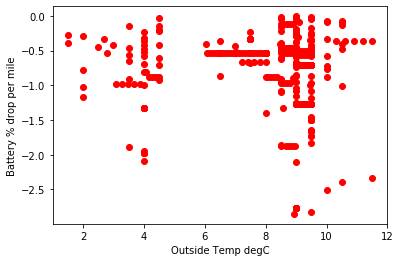

```python
temp = np.array(df["StevesCar..response.climate_state.outside_temp"])[0:-2]
speed = np.array(df["StevesCar..response.drive_state.speed"])[0:-2]

temp2 = temp[np.where(eff>-3)]
temp3 = temp2[np.where(eff2<0)]
speed2 = speed[np.where(eff>-3)]
speed3 = speed2[np.where(eff2<0)]

plt.plot(speed3, eff3, 'bo')
plt.xlim([0, 60])
plt.ylabel('Battery % drop per mile')
plt.xlabel('Speed mph')
plt.show()

plt.plot(temp3, eff3, 'ro')
plt.ylabel('Battery % drop per mile')
plt.xlabel('Outside Temp degC')
plt.show()
```

**Measuring the effect of heating the driver's seat**

- We were also able to isolate this measurement and compare efficiency w.r.t. right seat heated/unheated.
- There does not seem to be a change!

```
2796
1922
```

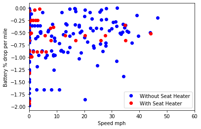

```python
sh = np.array(df["StevesCar..response.climate_state.seat_heater_right"])[0:-2]

eff_without_sh = eff[np.where(sh==0)]
eff_with_sh = eff[np.where(sh>0)]

print(len(eff_without_sh))
print(len(eff_with_sh))

eff2_without= eff_without_sh[np.where(eff_without_sh>-2)]
eff3_without = eff2_without[np.where(eff2_without<0)]

speed_without = speed[np.where(sh==0)]
speed2_without = speed_without[np.where(eff_without_sh>-2)]
speed3_without = speed2_without[np.where(eff2_without<0)]

eff2_with= eff_with_sh[np.where(eff_with_sh>-2)]
eff3_with = eff2_with[np.where(eff2_with<0)]

speed_with = speed[np.where(sh>0)]
speed2_with = speed_with[np.where(eff_with_sh>-2)]
speed3_with = speed2_with[np.where(eff2_with<0)]

plt.plot(speed3_without, eff3_without, 'bo', label='Without Seat Heater')
plt.plot(speed3_with, eff3_with, 'ro',label='With Seat Heater')
plt.xlim([0, 60])
plt.xlabel('Speed mph')
plt.ylabel('Battery % drop per mile')
plt.legend()
plt.show()
```

# If we had more time...

- Investigate the dataset in-depth
- Discover new relations
- Train a regression model to predict efficiency